# labmeet slides

## Julia Programming Language

- Numerical computing
- High-performance
- Proposed solution to the "two-language" problem:
  - Create prototype in Python/R/Matlab
  - Rewrite efficient implementation in Assembly/C/Fortran/C++

## Benchmarks

Taken from https://julialang.org/benchmarks/

## Language design

- LLVM: Compiler Infrastructure Project
- A language-independent intermediate representation
- LLVM can be used to compile many languages to machine-code:
  - `clang`: C, C++, Objective-C
  - D, Delphi,
  - Fortran, Haskell
  - Rust, Swift

[figure not shown]

```
timestwo(x::Int64) = x * 2
@code_llvm timestwo(2)
```

Result:

```
;  @ In[32]:1 within `timestwo`
define i64 @julia_timestwo_20586(i64 signext %0) #0 {
top:
; ┌ @ int.jl:88 within `*`
   %1 = shl i64 %0, 1
; └
  ret i64 %1
}
```

```julia
# Basic types

x = 0
y = 3.1415
z = "mystring"
m = Float16(3.0)
c = 3.0 + 3im

# Arrays
v = [1.0, 2.0, 3.0]
A = [1.1 2.1 3.5
     4.9 5.3 6.0
     7.8 8.1 9.3]
```

```
3×3 Matrix{Float64}:
 1.1  2.1  3.5
 4.9  5.3  6.0
 7.8  8.1  9.3
```

```julia
# Basic loop
l = []
for i = 1:10
    append!(l, i)
end
println(l)

# Iterators
l2 = Int32[]
for (i, item) in enumerate(10:20)
    append!(l2, i * item)
end
println(l2)

# Vector comprehension
l = [i for i in 1:10]

# Dict comprehension
taxa = ["bird", "rat", "dog", "bat"]
flying = [1, 0, 0, 1]

d = Dict(taxon => f for (taxon, f) in zip(taxa, flying))
```

```
Any[1, 2, 3, 4, 5, 6, 7, 8, 9, 10]
Int32[10, 22, 36, 52, 70, 90, 112, 136, 162, 190, 220]
```

```
Dict{String, Int64} with 4 entries:
  "bat"  => 1
  "rat"  => 0
  "bird" => 1
  "dog"  => 0
```

```julia
# Functions
function foo(x)
    return x + 2
end

bar(x) = begin
    x + sin(x)
end

foobar(x, y) = sin(x) + cos(y)

foobaz = x -> sin(x) + 2
```

```
#5 (generic function with 1 method)
```

```julia
# If statements

if false
    println("A")
elseif true
    println("B")
else
    println("C")
end
```

```
B
```

```julia
# Splatting operator
baz(a,b) = a + b;

args = [1, 2]

baz(args...)
```

```
3
```

```julia
# The reverse
x1 = 2.0
x2 = 3.0

function bazfoo(args...)
    res = 0.0
    for item in args
        res += item
    end
    return res
end

bazfoo(x1, x2)
```

```
5.0
```

```julia
# scope of variables
local c = 0.0

for i in 1:2
    println(c)
end
```

```
UndefVarError: c not defined

Stacktrace:
 [1] top-level scope
   @ .\In[9]:4
 [2] eval
   @ .\boot.jl:373 [inlined]
 [3] include_string(mapexpr::typeof(REPL.softscope), mod::Module, code::String, filename::String)
   @ Base .\loading.jl:1196
```

## Multiple dispatch

```julia
function timestwo(x::Int64)
    return x * 2
end

function timestwo(x::Float64)
    return x * 2.0
end
```

```
timestwo (generic function with 2 methods)
```

## Same method compiled and optimized for different types

`@code_native timestwo(2)`

```
.text
; ┌ @ In[137]:4 within `timestwo'
; │┌ @ int.jl:88 within `*'
    leaq    (%rdi,%rdi), %rax
; │└
    retq
    nopw    %cs:(%rax,%rax)
; └
```

`@code_native timestwo(2.0)`

```
    .text
; ┌ @ In[137]:8 within `timestwo'
; │┌ @ float.jl:332 within `*'
    vaddsd  %xmm0, %xmm0, %xmm0
; │└
    retq
    nopw    %cs:(%rax,%rax)
; └
```

```julia
methods(+)
```

# 206 methods for generic function **+**:

- +(x::**T**, y::**T**) *where T<:Union{Int128, Int16, Int32, Int64, Int8, UInt128, UInt16, UInt32, UInt64, UInt8}* in Base at [int.jl:87](https://github.com/JuliaLang/julia/tree/36034abf26062acad4af9dcec7c4fc53b260dbb4/base/int.jl#L87)

- +(x::**T**, y::**T**) *where T<:Union{Float16, Float32, Float64}* in Base at [float.jl:383](https://github.com/JuliaLang/julia/tree/36034abf26062acad4af9dcec7c4fc53b260dbb4/base/float.jl#L383)

- +(c::**Union{UInt16, UInt32, UInt64, UInt8}**, x::**BigInt**) in Base.GMP at [gmp.jl:531](https://github.com/JuliaLang/julia/tree/36034abf26062acad4af9dcec7c4fc53b260dbb4/base/gmp.jl#L531)

- +(c::**Union{Int16, Int32, Int64, Int8}**, x::**BigInt**) in Base.GMP at [gmp.jl:537](https://github.com/JuliaLang/julia/tree/36034abf26062acad4af9dcec7c4fc53b260dbb4/base/gmp.jl#L537)

- +(c::**Union{UInt16, UInt32, UInt64, UInt8}**, x::**BigFloat**) in Base.MPFR at [mpfr.jl:398](https://github.com/JuliaLang/julia/tree/36034abf26062acad4af9dcec7c4fc53b260dbb4/base/mpfr.jl#L398)

- +(c::**Union{Int16, Int32, Int64, Int8}**, x::**BigFloat**) in Base.MPFR at [mpfr.jl:406](https://github.com/JuliaLang/julia/tree/36034abf26062acad4af9dcec7c4fc53b260dbb4/base/mpfr.jl#L406)

- +(c::**Union{Float16, Float32, Float64}**, x::**BigFloat**) in Base.MPFR at [mpfr.jl:414](https://github.com/JuliaLang/julia/tree/36034abf26062acad4af9dcec7c4fc53b260dbb4/base/mpfr.jl#L414)

- +(x::**Union{Dates.CompoundPeriod, Dates.Period}**) in Dates at /home/bkopper/julia-1.8.2/share/julia/stdlib/v1.8/Dates/src/periods.jl:378

- +(A::**LinearAlgebra.Hermitian**, B::**LinearAlgebra.Hermitian**) in LinearAlgebra at /home/bkopper/julia-1.8.2/share/julia/stdlib/v1.8/LinearAlgebra/src/symmetric.jl:469

- +(A::**LinearAlgebra.Hermitian**, B::**LinearAlgebra.SymTridiagonal{var"#s882", V} where {var"#s882"<:Real, V<:AbstractVector{var"#s882"}}**) in LinearAlgebra at /home/bkopper/julia-1.8.2/share/julia/stdlib/v1.8/LinearAlgebra/src/symmetric.jl:488

- +(H::**LinearAlgebra.Hermitian**, D::**LinearAlgebra.Diagonal{var"#s885", V} where {var"#s885"<:Real, V<:AbstractVector{var"#s885"}}**) in LinearAlgebra at /home/bkopper/julia-1.8.2/share/julia/stdlib/v1.8/LinearAlgebra/src/diagonal.jl:197

- +(A::**LinearAlgebra.Hermitian**, J::**LinearAlgebra.UniformScaling{<:Complex}**) in LinearAlgebra at /home/bkopper/julia-1.8.2/share/julia/stdlib/v1.8/LinearAlgebra/src/uniformscaling.jl:195

- +(A::**LinearAlgebra.Hermitian{<:Any, <:SparseArrays.AbstractSparseMatrix}**, B::**SparseArrays.AbstractSparseMatrix**) in SparseArrays at /home/bkopper/julia-1.8.2/share/julia/stdlib/v1.8/SparseArrays/src/linalg.jl:15

- +(A::**LinearAlgebra.Hermitian**, B::**SparseArrays.AbstractSparseMatrix**) in SparseArrays at /home/bkopper/julia-1.8.2/share/julia/stdlib/v1.8/SparseArrays/src/linalg.jl:18

- +(A::**LinearAlgebra.Hermitian{<:Any, <:SparseArrays.AbstractSparseMatrix}**, B::**LinearAlgebra.Symmetric{<:Real, <:SparseArrays.AbstractSparseMatrix}**) in SparseArrays at /home/bkopper/julia-1.8.2/share/julia/stdlib/v1.8/SparseArrays/src/linalg.jl:26

- +(A::**LinearAlgebra.Hermitian**, B::**LinearAlgebra.Symmetric{var"#s885", S} where {var"#s885"<:Real, S<:(AbstractMatrix{<:var"#s885"})}**) in LinearAlgebra at /home/bkopper/julia-1.8.2/share/julia/stdlib/v1.8/LinearAlgebra/src/symmetric.jl:483

- +(A::**LinearAlgebra.Hermitian{<:Any, <:SparseArrays.AbstractSparseMatrix}**, B::**LinearAlgebra.Symmetric{<:Any, <:SparseArrays.AbstractSparseMatrix}**) in SparseArrays at /home/bkopper/julia-1.8.2/share/julia/stdlib/v1.8/SparseArrays/src/linalg.jl:24

- +(x::**P**, y::**P**) *where P<:Dates.Period* in Dates at /home/bkopper/julia-1.8.2/share/julia/stdlib/v1.8/Dates/src/periods.jl:77

- +(x::**Dates.Period**, y::**Dates.Period**) in Dates at /home/bkopper/julia-1.8.2/share/julia/stdlib/v1.8/Dates/src/periods.jl:367

- +(y::**Dates.Period**, x::**Dates.CompoundPeriod**) in Dates at /home/bkopper/julia-1.8.2/share/julia/stdlib/v1.8/Dates/src/periods.jl:369

- +(y::**Dates.Period**, x::**Dates.TimeType**) in Dates at /home/bkopper/julia-1.8.2/share/julia/stdlib/v1.8/Dates/src/arithmetic.jl:85

- +(x::**Dates.Period**, r::**AbstractRange{<:Dates.TimeType}**) in Dates at /home/bkopper/julia-1.8.2/share/julia/stdlib/v1.8/Dates/src/ranges.jl:63

- +(y::**Union{Dates.CompoundPeriod, Dates.Period}**, x::**AbstractArray{<:Dates.TimeType}**) in Dates at /home/bkopper/julia-1.8.2/share/julia/stdlib/v1.8/Dates/src/deprecated.jl:14

- +(A::**SparseArrays.AbstractSparseMatrix**, B::**LinearAlgebra.Hermitian{<:Any, <:SparseArrays.AbstractSparseMatrix}**) in SparseArrays at /home/bkopper/julia-1.8.2/share/julia/stdlib/v1.8/SparseArrays/src/linalg.jl:14

- +(A::**SparseArrays.AbstractSparseMatrix**, B::**LinearAlgebra.Hermitian**) in SparseArrays at /home/bkopper/julia-1.8.2/share/julia/stdlib/v1.8/SparseArrays/src/linalg.jl:17

- +(A::**SparseArrays.AbstractSparseMatrix**, B::**LinearAlgebra.Symmetric{<:Any, <:SparseArrays.AbstractSparseMatrix}**) in SparseArrays at /home/bkopper/julia-1.8.2/share/julia/stdlib/v1.8/SparseArrays/src/linalg.jl:14

- +(A::**SparseArrays.AbstractSparseMatrix**, B::**LinearAlgebra.Symmetric**) in SparseArrays at /home/bkopper/julia-1.8.2/share/julia/stdlib/v1.8/SparseArrays/src/linalg.jl:17

- +(A::**LinearAlgebra.UpperTriangular**, B::**LinearAlgebra.UpperTriangular**) in LinearAlgebra at /home/bkopper/julia-1.8.2/share/julia/stdlib/v1.8/LinearAlgebra/src/triangular.jl:638

- +(A::**LinearAlgebra.UpperTriangular**, B::**LinearAlgebra.UnitUpperTriangular**) in LinearAlgebra at /home/bkopper/julia-1.8.2/share/julia/stdlib/v1.8/LinearAlgebra/src/triangular.jl:640

- +(x::**LinearAlgebra.UpperTriangular**, H::**LinearAlgebra.UpperHessenberg**) in LinearAlgebra at /home/bkopper/julia-1.8.2/share/julia/stdlib/v1.8/LinearAlgebra/src/hessenberg.jl:109

- +(A::**LinearAlgebra.UpperTriangular**, B::**LinearAlgebra.Bidiagonal**) in LinearAlgebra at /home/bkopper/julia-1.8.2/share/julia/stdlib/v1.8/LinearAlgebra/src/special.jl:98

- +(A::**BitArray**, B::**BitArray**) in Base at [bitarray.jl:1184](https://github.com/JuliaLang/julia/tree/36034abf26062acad4af9dcec7c4fc53b260dbb4/base/bitarray.jl#L1184)

- +(A::**LinearAlgebra.UnitUpperTriangular**, B::**LinearAlgebra.UpperTriangular**) in LinearAlgebra at /home/bkopper/julia-1.8.2/share/julia/stdlib/v1.8/LinearAlgebra/src/triangular.jl:642

- +(A::**LinearAlgebra.UnitUpperTriangular**, B::**LinearAlgebra.UnitUpperTriangular**) in LinearAlgebra at /home/bkopper/julia-1.8.2/share/julia/stdlib/v1.8/LinearAlgebra/src/triangular.jl:644

- +(UL::**LinearAlgebra.UnitUpperTriangular**, J::**LinearAlgebra.UniformScaling**) in LinearAlgebra at /home/bkopper/julia-1.8.2/share/julia/stdlib/v1.8/LinearAlgebra/src/uniformscaling.jl:181

- +(x::**LinearAlgebra.UnitUpperTriangular**, H::**LinearAlgebra.UpperHessenberg**) in LinearAlgebra at /home/bkopper/julia-1.8.2/share/julia/stdlib/v1.8/LinearAlgebra/src/hessenberg.jl:109

- +(A::**LinearAlgebra.UnitUpperTriangular**, B::**LinearAlgebra.Bidiagonal**) in LinearAlgebra at /home/bkopper/julia-1.8.2/share/julia/stdlib/v1.8/LinearAlgebra/src/special.jl:98

- +(z::**Complex**, w::**Complex**) in Base at [complex.jl:288](https://github.com/JuliaLang/julia/tree/36034abf26062acad4af9dcec7c4fc53b260dbb4/base/complex.jl#L288)

- +(Da::**LinearAlgebra.Diagonal**, Db::**LinearAlgebra.Diagonal**) in LinearAlgebra at /home/bkopper/julia-1.8.2/share/julia/stdlib/v1.8/LinearAlgebra/src/diagonal.jl:184

- +(D::**LinearAlgebra.Diagonal**, S::**LinearAlgebra.Symmetric**) in LinearAlgebra at /home/bkopper/julia-1.8.2/share/julia/stdlib/v1.8/LinearAlgebra/src/diagonal.jl:188

- +(D::**LinearAlgebra.Diagonal{var"#s885", V} where {var"#s885"<:Real, V<:AbstractVector{var"#s885"}}**, H::**LinearAlgebra.Hermitian**) in LinearAlgebra at /home/bkopper/julia-1.8.2/share/julia/stdlib/v1.8/LinearAlgebra/src/diagonal.jl:194

- +(x::**LinearAlgebra.Diagonal**, H::**LinearAlgebra.UpperHessenberg**) in LinearAlgebra at /home/bkopper/julia-1.8.2/share/julia/stdlib/v1.8/LinearAlgebra/src/hessenberg.jl:109

- +(A::**LinearAlgebra.Diagonal**, B::**LinearAlgebra.Bidiagonal**) in LinearAlgebra at /home/bkopper/julia-1.8.2/share/julia/stdlib/v1.8/LinearAlgebra/src/special.jl:137

- +(A::**LinearAlgebra.Diagonal**, B::**LinearAlgebra.SymTridiagonal**) in LinearAlgebra at /home/bkopper/julia-1.8.2/share/julia/stdlib/v1.8/LinearAlgebra/src/special.jl:147

- +(A::**LinearAlgebra.Diagonal**, B::**LinearAlgebra.Tridiagonal**) in LinearAlgebra at /home/bkopper/julia-1.8.2/share/julia/stdlib/v1.8/LinearAlgebra/src/special.jl:175

- +(A::**LinearAlgebra.Diagonal{var"#s885", V} where {var"#s885"<:Number, V<:AbstractVector{var"#s885"}}**, B::**LinearAlgebra.UniformScaling**) in LinearAlgebra at /home/bkopper/julia-1.8.2/share/julia/stdlib/v1.8/LinearAlgebra/src/special.jl:253

- +(r1::**LinRange{T}**, r2::**LinRange{T}**) *where T* in Base at [range.jl:1431](https://github.com/JuliaLang/julia/tree/36034abf26062acad4af9dcec7c4fc53b260dbb4/base/range.jl#L1431)

- +(x::**Rational**, y::**Integer**) in Base at [rational.jl:313](https://github.com/JuliaLang/julia/tree/36034abf26062acad4af9dcec7c4fc53b260dbb4/base/rational.jl#L313)

- +(x::**AbstractIrrational**, y::**AbstractIrrational**) in Base at [irrationals.jl:158](https://github.com/JuliaLang/julia/tree/36034abf26062acad4af9dcec7c4fc53b260dbb4/base/irrationals.jl#L158)

- +(A::**LinearAlgebra.UnitLowerTriangular**, B::**LinearAlgebra.LowerTriangular**) in LinearAlgebra at /home/bkopper/julia-1.8.2/share/julia/stdlib/v1.8/LinearAlgebra/src/triangular.jl:643

- +(A::**LinearAlgebra.UnitLowerTriangular**, B::**LinearAlgebra.UnitLowerTriangular**) in LinearAlgebra at /home/bkopper/julia-1.8.2/share/julia/stdlib/v1.8/LinearAlgebra/src/triangular.jl:645

- +(UL::**LinearAlgebra.UnitLowerTriangular**, J::**LinearAlgebra.UniformScaling**) in LinearAlgebra at /home/bkopper/julia-1.8.2/share/julia/stdlib/v1.8/LinearAlgebra/src/uniformscaling.jl:181

- +(A::**LinearAlgebra.UnitLowerTriangular**, B::**LinearAlgebra.Bidiagonal**) in LinearAlgebra at /home/bkopper/julia-1.8.2/share/julia/stdlib/v1.8/LinearAlgebra/src/special.jl:98

- +(x::**T**, y::**Integer**) *where T<:AbstractChar* in Base at [char.jl:237](https://github.com/JuliaLang/julia/tree/36034abf26062acad4af9dcec7c4fc53b260dbb4/base/char.jl#L237)

- +(A::**LinearAlgebra.SymTridiagonal**, B::**LinearAlgebra.SymTridiagonal**) in LinearAlgebra at /home/bkopper/julia-1.8.2/share/julia/stdlib/v1.8/LinearAlgebra/src/tridiag.jl:207

- +(A::**LinearAlgebra.SymTridiagonal**, B::**LinearAlgebra.Symmetric**) in LinearAlgebra at /home/bkopper/julia-1.8.2/share/julia/stdlib/v1.8/LinearAlgebra/src/symmetric.jl:485

- +(A::**LinearAlgebra.SymTridiagonal{var"#s883", V} where {var"#s883"<:Real, V<:AbstractVector{var"#s883"}}**, B::**LinearAlgebra.Hermitian**) in LinearAlgebra at /home/bkopper/julia-1.8.2/share/julia/stdlib/v1.8/LinearAlgebra/src/symmetric.jl:487

- +(x::**LinearAlgebra.SymTridiagonal**, H::**LinearAlgebra.UpperHessenberg**) in LinearAlgebra at /home/bkopper/julia-1.8.2/share/julia/stdlib/v1.8/LinearAlgebra/src/hessenberg.jl:109

- +(A::**LinearAlgebra.SymTridiagonal**, B::**LinearAlgebra.Diagonal**) in LinearAlgebra at /home/bkopper/julia-1.8.2/share/julia/stdlib/v1.8/LinearAlgebra/src/special.jl:157

- +(A::**LinearAlgebra.SymTridiagonal**, B::**LinearAlgebra.Tridiagonal**) in LinearAlgebra at /home/bkopper/julia-1.8.2/share/julia/stdlib/v1.8/LinearAlgebra/src/special.jl:171

- +(A::**LinearAlgebra.SymTridiagonal**, B::**LinearAlgebra.Bidiagonal**) in LinearAlgebra at /home/bkopper/julia-1.8.2/share/julia/stdlib/v1.8/LinearAlgebra/src/special.jl:225

- +(A::**LinearAlgebra.SymTridiagonal{var"#s885", V} where {var"#s885"<:Number, V<:AbstractVector{var"#s885"}}**, B::**LinearAlgebra.UniformScaling**) in LinearAlgebra at /home/bkopper/julia-1.8.2/share/julia/stdlib/v1.8/LinearAlgebra/src/special.jl:243

- +(A::**LinearAlgebra.LowerTriangular**, B::**LinearAlgebra.LowerTriangular**) in LinearAlgebra at /home/bkopper/julia-1.8.2/share/julia/stdlib/v1.8/LinearAlgebra/src/triangular.jl:639

- +(A::**LinearAlgebra.LowerTriangular**, B::**LinearAlgebra.UnitLowerTriangular**) in LinearAlgebra at /home/bkopper/julia-1.8.2/share/julia/stdlib/v1.8/LinearAlgebra/src/triangular.jl:641

- +(A::**LinearAlgebra.LowerTriangular**, B::**LinearAlgebra.Bidiagonal**) in LinearAlgebra at /home/bkopper/julia-1.8.2/share/julia/stdlib/v1.8/LinearAlgebra/src/special.jl:98

- +(A::**LinearAlgebra.Tridiagonal**, B::**LinearAlgebra.Tridiagonal**) in LinearAlgebra at /home/bkopper/julia-1.8.2/share/julia/stdlib/v1.8/LinearAlgebra/src/tridiag.jl:741

- +(x::**LinearAlgebra.Tridiagonal**, H::**LinearAlgebra.UpperHessenberg**) in LinearAlgebra at /home/bkopper/julia-1.8.2/share/julia/stdlib/v1.8/LinearAlgebra/src/hessenberg.jl:109

- +(A::**LinearAlgebra.Tridiagonal**, B::**LinearAlgebra.SymTridiagonal**) in LinearAlgebra at /home/bkopper/julia-1.8.2/share/julia/stdlib/v1.8/LinearAlgebra/src/special.jl:169

- +(A::**LinearAlgebra.Tridiagonal**, B::**LinearAlgebra.Diagonal**) in LinearAlgebra at /home/bkopper/julia-1.8.2/share/julia/stdlib/v1.8/LinearAlgebra/src/special.jl:185

- +(A::**LinearAlgebra.Tridiagonal**, B::**LinearAlgebra.Bidiagonal**) in LinearAlgebra at /home/bkopper/julia-1.8.2/share/julia/stdlib/v1.8/LinearAlgebra/src/special.jl:205

- +(A::**LinearAlgebra.Tridiagonal{var"#s885", V} where {var"#s885"<:Number, V<:AbstractVector{var"#s885"}}**, B::**LinearAlgebra.UniformScaling**) in LinearAlgebra at /home/bkopper/julia-1.8.2/share/julia/stdlib/v1.8/LinearAlgebra/src/special.jl:238

- +(index1::**CartesianIndex{N}**, index2::**CartesianIndex{N}**) *where N* in Base.IteratorsMD at [multidimensional.jl:114](https://github.com/JuliaLang/julia/tree/36034abf26062acad4af9dcec7c4fc53b260dbb4/base/multidimensional.jl#L114)

- +(r1::**OrdinalRange**, r2::**OrdinalRange**) in Base at [range.jl:1424](https://github.com/JuliaLang/julia/tree/36034abf26062acad4af9dcec7c4fc53b260dbb4/base/range.jl#L1424)

- +(y::**AbstractFloat**, x::**Bool**) in Base at [bool.jl:172](https://github.com/JuliaLang/julia/tree/36034abf26062acad4af9dcec7c4fc53b260dbb4/base/bool.jl#L172)

- +(y::**Dates.TimeType**, x::**StridedArray{<:Union{Dates.CompoundPeriod, Dates.Period}}**) in Dates at /home/bkopper/julia-1.8.2/share/julia/stdlib/v1.8/Dates/src/deprecated.jl:18

- +(x::**Dates.Instant**) in Dates at /home/bkopper/julia-1.8.2/share/julia/stdlib/v1.8/Dates/src/arithmetic.jl:4

- +(A::**LinearAlgebra.Bidiagonal**, B::**LinearAlgebra.Bidiagonal**) in LinearAlgebra at /home/bkopper/julia-1.8.2/share/julia/stdlib/v1.8/LinearAlgebra/src/bidiag.jl:365

- +(x::**LinearAlgebra.Bidiagonal**, H::**LinearAlgebra.UpperHessenberg**) in LinearAlgebra at /home/bkopper/julia-1.8.2/share/julia/stdlib/v1.8/LinearAlgebra/src/hessenberg.jl:109

- +(A::**LinearAlgebra.Bidiagonal**, B::**LinearAlgebra.UpperTriangular**) in LinearAlgebra at /home/bkopper/julia-1.8.2/share/julia/stdlib/v1.8/LinearAlgebra/src/special.jl:106

- +(A::**LinearAlgebra.Bidiagonal**, B::**LinearAlgebra.UnitUpperTriangular**) in LinearAlgebra at /home/bkopper/julia-1.8.2/share/julia/stdlib/v1.8/LinearAlgebra/src/special.jl:106

- +(A::**LinearAlgebra.Bidiagonal**, B::**LinearAlgebra.LowerTriangular**) in LinearAlgebra at /home/bkopper/julia-1.8.2/share/julia/stdlib/v1.8/LinearAlgebra/src/special.jl:106

- +(A::**LinearAlgebra.Bidiagonal**, B::**LinearAlgebra.UnitLowerTriangular**) in LinearAlgebra at /home/bkopper/julia-1.8.2/share/julia/stdlib/v1.8/LinearAlgebra/src/special.jl:106

- +(A::**LinearAlgebra.Bidiagonal**, B::**LinearAlgebra.Diagonal**) in LinearAlgebra at /home/bkopper/julia-1.8.2/share/julia/stdlib/v1.8/LinearAlgebra/src/special.jl:127

- +(A::**LinearAlgebra.Bidiagonal**, B::**LinearAlgebra.Tridiagonal**) in LinearAlgebra at /home/bkopper/julia-1.8.2/share/julia/stdlib/v1.8/LinearAlgebra/src/special.jl:195

- +(A::**LinearAlgebra.Bidiagonal**, B::**LinearAlgebra.SymTridiagonal**) in LinearAlgebra at /home/bkopper/julia-1.8.2/share/julia/stdlib/v1.8/LinearAlgebra/src/special.jl:215

- +(A::**LinearAlgebra.Bidiagonal{var"#s885", V} where {var"#s885"<:Number, V<:AbstractVector{var"#s885"}}**, B::**LinearAlgebra.UniformScaling**) in LinearAlgebra at /home/bkopper/julia-1.8.2/share/julia/stdlib/v1.8/LinearAlgebra/src/special.jl:248

- +(x::**Ptr**, y::**Integer**) in Base at [pointer.jl:159](https://github.com/JuliaLang/julia/tree/36034abf26062acad4af9dcec7c4fc53b260dbb4/base/pointer.jl#L159)

- +(A::**SparseArrays.AbstractSparseMatrixCSC**, B::**SparseArrays.AbstractSparseMatrixCSC**) in SparseArrays at /home/bkopper/julia-1.8.2/share/julia/stdlib/v1.8/SparseArrays/src/sparsematrix.jl:1829

- +(x::**SparseArrays.AbstractSparseVector**, y::**SparseArrays.AbstractSparseVector**) in SparseArrays at /home/bkopper/julia-1.8.2/share/julia/stdlib/v1.8/SparseArrays/src/sparsevector.jl:1384

- +(A::**SparseArrays.AbstractSparseMatrixCSC**, B::**Array**) in SparseArrays at /home/bkopper/julia-1.8.2/share/julia/stdlib/v1.8/SparseArrays/src/sparsematrix.jl:1832

- +(A::**SparseArrays.AbstractSparseMatrixCSC**, J::**LinearAlgebra.UniformScaling**) in SparseArrays at /home/bkopper/julia-1.8.2/share/julia/stdlib/v1.8/SparseArrays/src/sparsematrix.jl:3821

- +(r::**AbstractRange{<:Dates.TimeType}**, x::**Dates.Period**) in Dates at /home/bkopper/julia-1.8.2/share/julia/stdlib/v1.8/Dates/src/ranges.jl:64

- +(x::**AbstractArray{<:Dates.TimeType}**, y::**Union{Dates.CompoundPeriod, Dates.Period}**) in Dates at /home/bkopper/julia-1.8.2/share/julia/stdlib/v1.8/Dates/src/deprecated.jl:6

- +(x::**Base.TwicePrecision**, y::**Number**) in Base at [twiceprecision.jl:290](https://github.com/JuliaLang/julia/tree/36034abf26062acad4af9dcec7c4fc53b260dbb4/base/twiceprecision.jl#L290)

- +(x::**Base.TwicePrecision{T}**, y::**Base.TwicePrecision{T}**) *where T* in Base at [twiceprecision.jl:296](https://github.com/JuliaLang/julia/tree/36034abf26062acad4af9dcec7c4fc53b260dbb4/base/twiceprecision.jl#L296)

- +(x::**Base.TwicePrecision**, y::**Base.TwicePrecision**) in Base at [twiceprecision.jl:301](https://github.com/JuliaLang/julia/tree/36034abf26062acad4af9dcec7c4fc53b260dbb4/base/twiceprecision.jl#L301)

- +(J::**LinearAlgebra.UniformScaling**) in LinearAlgebra at /home/bkopper/julia-1.8.2/share/julia/stdlib/v1.8/LinearAlgebra/src/uniformscaling.jl:149

- +(J::**LinearAlgebra.UniformScaling**, x::**Number**) in LinearAlgebra at /home/bkopper/julia-1.8.2/share/julia/stdlib/v1.8/LinearAlgebra/src/uniformscaling.jl:144

- +(J1::**LinearAlgebra.UniformScaling**, J2::**LinearAlgebra.UniformScaling**) in LinearAlgebra at /home/bkopper/julia-1.8.2/share/julia/stdlib/v1.8/LinearAlgebra/src/uniformscaling.jl:150

- +(J::**LinearAlgebra.UniformScaling**, B::**BitMatrix**) in LinearAlgebra at /home/bkopper/julia-1.8.2/share/julia/stdlib/v1.8/LinearAlgebra/src/uniformscaling.jl:152

- +(x::**LinearAlgebra.UniformScaling**, H::**LinearAlgebra.UpperHessenberg**) in LinearAlgebra at /home/bkopper/julia-1.8.2/share/julia/stdlib/v1.8/LinearAlgebra/src/hessenberg.jl:109

- +(J::**LinearAlgebra.UniformScaling**, F::**LinearAlgebra.Hessenberg**) in LinearAlgebra at /home/bkopper/julia-1.8.2/share/julia/stdlib/v1.8/LinearAlgebra/src/hessenberg.jl:642

- +(A::**LinearAlgebra.UniformScaling**, B::**LinearAlgebra.Tridiagonal{var"#s885", V} where {var"#s885"<:Number, V<:AbstractVector{var"#s885"}}**) in LinearAlgebra at /home/bkopper/julia-1.8.2/share/julia/stdlib/v1.8/LinearAlgebra/src/special.jl:257

- +(A::**LinearAlgebra.UniformScaling**, B::**LinearAlgebra.SymTridiagonal{var"#s885", V} where {var"#s885"<:Number, V<:AbstractVector{var"#s885"}}**) in LinearAlgebra at /home/bkopper/julia-1.8.2/share/julia/stdlib/v1.8/LinearAlgebra/src/special.jl:262

- +(A::**LinearAlgebra.UniformScaling**, B::**LinearAlgebra.Bidiagonal{var"#s885", V} where {var"#s885"<:Number, V<:AbstractVector{var"#s885"}}**) in LinearAlgebra at /home/bkopper/julia-1.8.2/share/julia/stdlib/v1.8/LinearAlgebra/src/special.jl:267

- +(A::**LinearAlgebra.UniformScaling**, B::**LinearAlgebra.Diagonal{var"#s885", V} where {var"#s885"<:Number, V<:AbstractVector{var"#s885"}}**) in LinearAlgebra at /home/bkopper/julia-1.8.2/share/julia/stdlib/v1.8/LinearAlgebra/src/special.jl:272

- +(J::**LinearAlgebra.UniformScaling**, A::**AbstractMatrix**) in LinearAlgebra at /home/bkopper/julia-1.8.2/share/julia/stdlib/v1.8/LinearAlgebra/src/uniformscaling.jl:153

- +(x::**Dates.AbstractTime**, y::**Missing**) in Dates at /home/bkopper/julia-1.8.2/share/julia/stdlib/v1.8/Dates/src/arithmetic.jl:88

- +(A::**LinearAlgebra.AbstractTriangular**, B::**LinearAlgebra.AbstractTriangular**) in LinearAlgebra at /home/bkopper/julia-1.8.2/share/julia/stdlib/v1.8/LinearAlgebra/src/triangular.jl:646

- +(F::**LinearAlgebra.Hessenberg**, J::**LinearAlgebra.UniformScaling**) in LinearAlgebra at /home/bkopper/julia-1.8.2/share/julia/stdlib/v1.8/LinearAlgebra/src/hessenberg.jl:641

- +(r1::**StepRangeLen{T, R}**, r2::**StepRangeLen{T, R}**) *where {R<:Base.TwicePrecision, T}* in Base at [twiceprecision.jl:644](https://github.com/JuliaLang/julia/tree/36034abf26062acad4af9dcec7c4fc53b260dbb4/base/twiceprecision.jl#L644)

- +(r1::**StepRangeLen{T, S}**, r2::**StepRangeLen{T, S}**) *where {T, S}* in Base at [range.jl:1447](https://github.com/JuliaLang/julia/tree/36034abf26062acad4af9dcec7c4fc53b260dbb4/base/range.jl#L1447)

- +(r1::**Union{LinRange, OrdinalRange, StepRangeLen}**, r2::**Union{LinRange, OrdinalRange, StepRangeLen}**) in Base at [range.jl:1440](https://github.com/JuliaLang/julia/tree/36034abf26062acad4af9dcec7c4fc53b260dbb4/base/range.jl#L1440)

- +(A::**LinearAlgebra.Symmetric**, B::**LinearAlgebra.Symmetric**) in LinearAlgebra at /home/bkopper/julia-1.8.2/share/julia/stdlib/v1.8/LinearAlgebra/src/symmetric.jl:469

- +(A::**LinearAlgebra.Symmetric**, B::**LinearAlgebra.SymTridiagonal**) in LinearAlgebra at /home/bkopper/julia-1.8.2/share/julia/stdlib/v1.8/LinearAlgebra/src/symmetric.jl:486

- +(S::**LinearAlgebra.Symmetric**, D::**LinearAlgebra.Diagonal**) in LinearAlgebra at /home/bkopper/julia-1.8.2/share/julia/stdlib/v1.8/LinearAlgebra/src/diagonal.jl:191

- +(A::**LinearAlgebra.Symmetric{<:Any, <:SparseArrays.AbstractSparseMatrix}**, B::**SparseArrays.AbstractSparseMatrix**) in SparseArrays at /home/bkopper/julia-1.8.2/share/julia/stdlib/v1.8/SparseArrays/src/linalg.jl:15

- +(A::**LinearAlgebra.Symmetric**, B::**SparseArrays.AbstractSparseMatrix**) in SparseArrays at /home/bkopper/julia-1.8.2/share/julia/stdlib/v1.8/SparseArrays/src/linalg.jl:18

- +(A::**LinearAlgebra.Symmetric{<:Real, <:SparseArrays.AbstractSparseMatrix}**, B::**LinearAlgebra.Hermitian{<:Any, <:SparseArrays.AbstractSparseMatrix}**) in SparseArrays at /home/bkopper/julia-1.8.2/share/julia/stdlib/v1.8/SparseArrays/src/linalg.jl:25

- +(A::**LinearAlgebra.Symmetric{var"#s884", S} where {var"#s884"<:Real, S<:(AbstractMatrix{<:var"#s884"})}**, B::**LinearAlgebra.Hermitian**) in LinearAlgebra at /home/bkopper/julia-1.8.2/share/julia/stdlib/v1.8/LinearAlgebra/src/symmetric.jl:484

- +(A::**LinearAlgebra.Symmetric{<:Any, <:SparseArrays.AbstractSparseMatrix}**, B::**LinearAlgebra.Hermitian{<:Any, <:SparseArrays.AbstractSparseMatrix}**) in SparseArrays at /home/bkopper/julia-1.8.2/share/julia/stdlib/v1.8/SparseArrays/src/linalg.jl:23

- +(A::**Array**, Bs::**Array...**) in Base at [arraymath.jl:12](https://github.com/JuliaLang/julia/tree/36034abf26062acad4af9dcec7c4fc53b260dbb4/base/arraymath.jl#L12)

- +(X::**StridedArray{<:Union{Dates.CompoundPeriod, Dates.Period}}**, Y::**StridedArray{<:Union{Dates.CompoundPeriod, Dates.Period}}**) in Dates at /home/bkopper/julia-1.8.2/share/julia/stdlib/v1.8/Dates/src/deprecated.jl:62

- +(A::**Array**, B::**SparseArrays.AbstractSparseMatrixCSC**) in SparseArrays at /home/bkopper/julia-1.8.2/share/julia/stdlib/v1.8/SparseArrays/src/sparsematrix.jl:1833

- +(x::**StridedArray{<:Union{Dates.CompoundPeriod, Dates.Period}}**) in Dates at /home/bkopper/julia-1.8.2/share/julia/stdlib/v1.8/Dates/src/deprecated.jl:55

- +(x::**StridedArray{<:Union{Dates.CompoundPeriod, Dates.Period}}**, y::**Dates.TimeType**) in Dates at /home/bkopper/julia-1.8.2/share/julia/stdlib/v1.8/Dates/src/deprecated.jl:10

- +(A::**LinearAlgebra.UpperHessenberg**, B::**LinearAlgebra.UpperHessenberg**) in LinearAlgebra at /home/bkopper/julia-1.8.2/share/julia/stdlib/v1.8/LinearAlgebra/src/hessenberg.jl:101

- +(H::**LinearAlgebra.UpperHessenberg**, x::**LinearAlgebra.UniformScaling**) in LinearAlgebra at /home/bkopper/julia-1.8.2/share/julia/stdlib/v1.8/LinearAlgebra/src/hessenberg.jl:108

- +(H::**LinearAlgebra.UpperHessenberg**, x::**LinearAlgebra.Diagonal**) in LinearAlgebra at /home/bkopper/julia-1.8.2/share/julia/stdlib/v1.8/LinearAlgebra/src/hessenberg.jl:108

- +(H::**LinearAlgebra.UpperHessenberg**, x::**LinearAlgebra.Bidiagonal**) in LinearAlgebra at /home/bkopper/julia-1.8.2/share/julia/stdlib/v1.8/LinearAlgebra/src/hessenberg.jl:108

- +(H::**LinearAlgebra.UpperHessenberg**, x::**LinearAlgebra.Tridiagonal**) in LinearAlgebra at /home/bkopper/julia-1.8.2/share/julia/stdlib/v1.8/LinearAlgebra/src/hessenberg.jl:108

- +(H::**LinearAlgebra.UpperHessenberg**, x::**LinearAlgebra.SymTridiagonal**) in LinearAlgebra at /home/bkopper/julia-1.8.2/share/julia/stdlib/v1.8/LinearAlgebra/src/hessenberg.jl:108

- +(H::**LinearAlgebra.UpperHessenberg**, x::**LinearAlgebra.UpperTriangular**) in LinearAlgebra at /home/bkopper/julia-1.8.2/share/julia/stdlib/v1.8/LinearAlgebra/src/hessenberg.jl:108

- +(H::**LinearAlgebra.UpperHessenberg**, x::**LinearAlgebra.UnitUpperTriangular**) in LinearAlgebra at /home/bkopper/julia-1.8.2/share/julia/stdlib/v1.8/LinearAlgebra/src/hessenberg.jl:108

- +(A::**AbstractArray**, B::**AbstractArray**) in Base at [arraymath.jl:6](https://github.com/JuliaLang/julia/tree/36034abf26062acad4af9dcec7c4fc53b260dbb4/base/arraymath.jl#L6)

- +(dt::**Dates.DateTime**, y::**Dates.Year**) in Dates at /home/bkopper/julia-1.8.2/share/julia/stdlib/v1.8/Dates/src/arithmetic.jl:23

- +(dt::**Dates.DateTime**, z::**Dates.Month**) in Dates at /home/bkopper/julia-1.8.2/share/julia/stdlib/v1.8/Dates/src/arithmetic.jl:47

- +(x::**Dates.DateTime**, y::**Dates.Quarter**) in Dates at /home/bkopper/julia-1.8.2/share/julia/stdlib/v1.8/Dates/src/arithmetic.jl:75

- +(x::**Dates.DateTime**, y::**Dates.Period**) in Dates at /home/bkopper/julia-1.8.2/share/julia/stdlib/v1.8/Dates/src/arithmetic.jl:81

- +(x::**BigInt**, c::**Union{UInt16, UInt32, UInt64, UInt8}**) in Base.GMP at [gmp.jl:530](https://github.com/JuliaLang/julia/tree/36034abf26062acad4af9dcec7c4fc53b260dbb4/base/gmp.jl#L530)

- +(x::**BigInt**, c::**Union{Int16, Int32, Int64, Int8}**) in Base.GMP at [gmp.jl:536](https://github.com/JuliaLang/julia/tree/36034abf26062acad4af9dcec7c4fc53b260dbb4/base/gmp.jl#L536)

- +(x::**BigInt**, y::**BigInt**) in Base.GMP at [gmp.jl:482](https://github.com/JuliaLang/julia/tree/36034abf26062acad4af9dcec7c4fc53b260dbb4/base/gmp.jl#L482)

- +(a::**BigInt**, b::**BigInt**, c::**BigInt**) in Base.GMP at [gmp.jl:522](https://github.com/JuliaLang/julia/tree/36034abf26062acad4af9dcec7c4fc53b260dbb4/base/gmp.jl#L522)

- +(a::**BigInt**, b::**BigInt**, c::**BigInt**, d::**BigInt**) in Base.GMP at [gmp.jl:523](https://github.com/JuliaLang/julia/tree/36034abf26062acad4af9dcec7c4fc53b260dbb4/base/gmp.jl#L523)

- +(a::**BigInt**, b::**BigInt**, c::**BigInt**, d::**BigInt**, e::**BigInt**) in Base.GMP at [gmp.jl:524](https://github.com/JuliaLang/julia/tree/36034abf26062acad4af9dcec7c4fc53b260dbb4/base/gmp.jl#L524)

- +(x::**BigInt**, y::**BigInt**, rest::**BigInt...**) in Base.GMP at [gmp.jl:657](https://github.com/JuliaLang/julia/tree/36034abf26062acad4af9dcec7c4fc53b260dbb4/base/gmp.jl#L657)

- +(c::**BigInt**, x::**BigFloat**) in Base.MPFR at [mpfr.jl:422](https://github.com/JuliaLang/julia/tree/36034abf26062acad4af9dcec7c4fc53b260dbb4/base/mpfr.jl#L422)

- +(x::**Dates.Time**, y::**Dates.TimePeriod**) in Dates at /home/bkopper/julia-1.8.2/share/julia/stdlib/v1.8/Dates/src/arithmetic.jl:83

- +(t::**Dates.Time**, dt::**Dates.Date**) in Dates at /home/bkopper/julia-1.8.2/share/julia/stdlib/v1.8/Dates/src/arithmetic.jl:20

- +(::**Missing**) in Base at [missing.jl:101](https://github.com/JuliaLang/julia/tree/36034abf26062acad4af9dcec7c4fc53b260dbb4/base/missing.jl#L101)

- +(::**Missing**, ::**Number**) in Base at [missing.jl:123](https://github.com/JuliaLang/julia/tree/36034abf26062acad4af9dcec7c4fc53b260dbb4/base/missing.jl#L123)

- +(x::**Missing**, y::**Dates.AbstractTime**) in Dates at /home/bkopper/julia-1.8.2/share/julia/stdlib/v1.8/Dates/src/arithmetic.jl:89

- +(::**Missing**, ::**Missing**) in Base at [missing.jl:122](https://github.com/JuliaLang/julia/tree/36034abf26062acad4af9dcec7c4fc53b260dbb4/base/missing.jl#L122)

- +(x::**Bool**) in Base at [bool.jl:159](https://github.com/JuliaLang/julia/tree/36034abf26062acad4af9dcec7c4fc53b260dbb4/base/bool.jl#L159)

- +(x::**Number**, y::**Base.TwicePrecision**) in Base at [twiceprecision.jl:294](https://github.com/JuliaLang/julia/tree/36034abf26062acad4af9dcec7c4fc53b260dbb4/base/twiceprecision.jl#L294)

- +(::**Number**, ::**Missing**) in Base at [missing.jl:124](https://github.com/JuliaLang/julia/tree/36034abf26062acad4af9dcec7c4fc53b260dbb4/base/missing.jl#L124)

- +(x::**Number**, J::**LinearAlgebra.UniformScaling**) in LinearAlgebra at /home/bkopper/julia-1.8.2/share/julia/stdlib/v1.8/LinearAlgebra/src/uniformscaling.jl:145

- +(x::**Integer**, y::**Ptr**) in Base at [pointer.jl:161](https://github.com/JuliaLang/julia/tree/36034abf26062acad4af9dcec7c4fc53b260dbb4/base/pointer.jl#L161)

- +(y::**Integer**, x::**Rational**) in Base at [rational.jl:320](https://github.com/JuliaLang/julia/tree/36034abf26062acad4af9dcec7c4fc53b260dbb4/base/rational.jl#L320)

- +(x::**Integer**, y::**AbstractChar**) in Base at [char.jl:247](https://github.com/JuliaLang/julia/tree/36034abf26062acad4af9dcec7c4fc53b260dbb4/base/char.jl#L247)

- +(x::**Bool**, y::**T**) *where T<:AbstractFloat* in Base at [bool.jl:169](https://github.com/JuliaLang/julia/tree/36034abf26062acad4af9dcec7c4fc53b260dbb4/base/bool.jl#L169)

- +(x::**Bool**, y::**Bool**) in Base at [bool.jl:162](https://github.com/JuliaLang/julia/tree/36034abf26062acad4af9dcec7c4fc53b260dbb4/base/bool.jl#L162)

- +(a::**Integer**, b::**Integer**) in Base at [int.jl:987](https://github.com/JuliaLang/julia/tree/36034abf26062acad4af9dcec7c4fc53b260dbb4/base/int.jl#L987)

- +(x::**Bool**, z::**Complex{Bool}**) in Base at [complex.jl:299](https://github.com/JuliaLang/julia/tree/36034abf26062acad4af9dcec7c4fc53b260dbb4/base/complex.jl#L299)

- +(x::**Real**, z::**Complex{Bool}**) in Base at [complex.jl:313](https://github.com/JuliaLang/julia/tree/36034abf26062acad4af9dcec7c4fc53b260dbb4/base/complex.jl#L313)

- +(x::**Bool**, z::**Complex**) in Base at [complex.jl:306](https://github.com/JuliaLang/julia/tree/36034abf26062acad4af9dcec7c4fc53b260dbb4/base/complex.jl#L306)

- +(x::**Real**, z::**Complex**) in Base at [complex.jl:325](https://github.com/JuliaLang/julia/tree/36034abf26062acad4af9dcec7c4fc53b260dbb4/base/complex.jl#L325)

- +(z::**Complex{Bool}**, x::**Bool**) in Base at [complex.jl:300](https://github.com/JuliaLang/julia/tree/36034abf26062acad4af9dcec7c4fc53b260dbb4/base/complex.jl#L300)

- +(z::**Complex**, x::**Bool**) in Base at [complex.jl:307](https://github.com/JuliaLang/julia/tree/36034abf26062acad4af9dcec7c4fc53b260dbb4/base/complex.jl#L307)

- +(z::**Complex{Bool}**, x::**Real**) in Base at [complex.jl:314](https://github.com/JuliaLang/julia/tree/36034abf26062acad4af9dcec7c4fc53b260dbb4/base/complex.jl#L314)

- +(z::**Complex**) in Base at [complex.jl:286](https://github.com/JuliaLang/julia/tree/36034abf26062acad4af9dcec7c4fc53b260dbb4/base/complex.jl#L286)

- +(z::**Complex**, x::**Real**) in Base at [complex.jl:326](https://github.com/JuliaLang/julia/tree/36034abf26062acad4af9dcec7c4fc53b260dbb4/base/complex.jl#L326)

- +(x::**Rational{BigInt}**, y::**Rational{BigInt}**) in Base.GMP.MPQ at [gmp.jl:922](https://github.com/JuliaLang/julia/tree/36034abf26062acad4af9dcec7c4fc53b260dbb4/base/gmp.jl#L922)

- +(x::**Rational**) in Base at [rational.jl:270](https://github.com/JuliaLang/julia/tree/36034abf26062acad4af9dcec7c4fc53b260dbb4/base/rational.jl#L270)

- +(x::**Rational**, y::**Rational**) in Base at [rational.jl:284](https://github.com/JuliaLang/julia/tree/36034abf26062acad4af9dcec7c4fc53b260dbb4/base/rational.jl#L284)

- +(level::**Base.CoreLogging.LogLevel**, inc::**Integer**) in Base.CoreLogging at [logging.jl:131](https://github.com/JuliaLang/julia/tree/36034abf26062acad4af9dcec7c4fc53b260dbb4/base/logging.jl#L131)

- +(B::**BitMatrix**, J::**LinearAlgebra.UniformScaling**) in LinearAlgebra at /home/bkopper/julia-1.8.2/share/julia/stdlib/v1.8/LinearAlgebra/src/uniformscaling.jl:151

- +(A::**AbstractMatrix**, J::**LinearAlgebra.UniformScaling**) in LinearAlgebra at /home/bkopper/julia-1.8.2/share/julia/stdlib/v1.8/LinearAlgebra/src/uniformscaling.jl:214

- +(x::**AbstractArray{<:Number}**) in Base at [abstractarraymath.jl:220](https://github.com/JuliaLang/julia/tree/36034abf26062acad4af9dcec7c4fc53b260dbb4/base/abstractarraymath.jl#L220)

- +(dt::**Dates.Date**, t::**Dates.Time**) in Dates at /home/bkopper/julia-1.8.2/share/julia/stdlib/v1.8/Dates/src/arithmetic.jl:19

- +(dt::**Dates.Date**, y::**Dates.Year**) in Dates at /home/bkopper/julia-1.8.2/share/julia/stdlib/v1.8/Dates/src/arithmetic.jl:27

- +(dt::**Dates.Date**, z::**Dates.Month**) in Dates at /home/bkopper/julia-1.8.2/share/julia/stdlib/v1.8/Dates/src/arithmetic.jl:54

- +(x::**Dates.Date**, y::**Dates.Quarter**) in Dates at /home/bkopper/julia-1.8.2/share/julia/stdlib/v1.8/Dates/src/arithmetic.jl:73

- +(x::**Dates.Date**, y::**Dates.Week**) in Dates at /home/bkopper/julia-1.8.2/share/julia/stdlib/v1.8/Dates/src/arithmetic.jl:77

- +(x::**Dates.Date**, y::**Dates.Day**) in Dates at /home/bkopper/julia-1.8.2/share/julia/stdlib/v1.8/Dates/src/arithmetic.jl:79

- +(x::**Dates.TimeType**) in Dates at /home/bkopper/julia-1.8.2/share/julia/stdlib/v1.8/Dates/src/arithmetic.jl:8

- +(a::**Dates.TimeType**, b::**Dates.Period**, c::**Dates.Period**) in Dates at /home/bkopper/julia-1.8.2/share/julia/stdlib/v1.8/Dates/src/periods.jl:389

- +(a::**Dates.TimeType**, b::**Dates.Period**, c::**Dates.Period**, d::**Dates.Period...**) in Dates at /home/bkopper/julia-1.8.2/share/julia/stdlib/v1.8/Dates/src/periods.jl:390

- +(x::**Dates.TimeType**, y::**Dates.CompoundPeriod**) in Dates at /home/bkopper/julia-1.8.2/share/julia/stdlib/v1.8/Dates/src/periods.jl:392

- +(x::**BigFloat**, c::**Union{UInt16, UInt32, UInt64, UInt8}**) in Base.MPFR at [mpfr.jl:393](https://github.com/JuliaLang/julia/tree/36034abf26062acad4af9dcec7c4fc53b260dbb4/base/mpfr.jl#L393)

- +(x::**BigFloat**, c::**Union{Int16, Int32, Int64, Int8}**) in Base.MPFR at [mpfr.jl:401](https://github.com/JuliaLang/julia/tree/36034abf26062acad4af9dcec7c4fc53b260dbb4/base/mpfr.jl#L401)

- +(x::**BigFloat**, c::**Union{Float16, Float32, Float64}**) in Base.MPFR at [mpfr.jl:409](https://github.com/JuliaLang/julia/tree/36034abf26062acad4af9dcec7c4fc53b260dbb4/base/mpfr.jl#L409)

- +(x::**BigFloat**, y::**BigFloat**) in Base.MPFR at [mpfr.jl:386](https://github.com/JuliaLang/julia/tree/36034abf26062acad4af9dcec7c4fc53b260dbb4/base/mpfr.jl#L386)

- +(x::**BigFloat**, c::**BigInt**) in Base.MPFR at [mpfr.jl:417](https://github.com/JuliaLang/julia/tree/36034abf26062acad4af9dcec7c4fc53b260dbb4/base/mpfr.jl#L417)

- +(a::**BigFloat**, b::**BigFloat**, c::**BigFloat**) in Base.MPFR at [mpfr.jl:558](https://github.com/JuliaLang/julia/tree/36034abf26062acad4af9dcec7c4fc53b260dbb4/base/mpfr.jl#L558)

- +(a::**BigFloat**, b::**BigFloat**, c::**BigFloat**, d::**BigFloat**) in Base.MPFR at [mpfr.jl:564](https://github.com/JuliaLang/julia/tree/36034abf26062acad4af9dcec7c4fc53b260dbb4/base/mpfr.jl#L564)

- +(a::**BigFloat**, b::**BigFloat**, c::**BigFloat**, d::**BigFloat**, e::**BigFloat**) in Base.MPFR at [mpfr.jl:571](https://github.com/JuliaLang/julia/tree/36034abf26062acad4af9dcec7c4fc53b260dbb4/base/mpfr.jl#L571)

- +(x::**Number**) in Base at [operators.jl:528](https://github.com/JuliaLang/julia/tree/36034abf26062acad4af9dcec7c4fc53b260dbb4/base/operators.jl#L528)

- +(x::**T**, y::**T**) *where T<:Number* in Base at [promotion.jl:463](https://github.com/JuliaLang/julia/tree/36034abf26062acad4af9dcec7c4fc53b260dbb4/base/promotion.jl#L463)

- +(x::**Number**, y::**Number**) in Base at [promotion.jl:388](https://github.com/JuliaLang/julia/tree/36034abf26062acad4af9dcec7c4fc53b260dbb4/base/promotion.jl#L388)

- +(x::**Dates.CompoundPeriod**, y::**Dates.Period**) in Dates at /home/bkopper/julia-1.8.2/share/julia/stdlib/v1.8/Dates/src/periods.jl:368

- +(x::**Dates.CompoundPeriod**, y::**Dates.TimeType**) in Dates at /home/bkopper/julia-1.8.2/share/julia/stdlib/v1.8/Dates/src/periods.jl:398

- +(x::**Dates.CompoundPeriod**, y::**Dates.CompoundPeriod**) in Dates at /home/bkopper/julia-1.8.2/share/julia/stdlib/v1.8/Dates/src/periods.jl:370

- +(a::**Pkg.Resolve.FieldValue**, b::**Pkg.Resolve.FieldValue**) in Pkg.Resolve at /home/bkopper/julia-1.8.2/share/julia/stdlib/v1.8/Pkg/src/Resolve/fieldvalues.jl:43

- +(a::**Pkg.Resolve.VersionWeight**, b::**Pkg.Resolve.VersionWeight**) in Pkg.Resolve at /home/bkopper/julia-1.8.2/share/julia/stdlib/v1.8/Pkg/src/Resolve/versionweights.jl:22

- +(a, b, c, xs...) in Base at [operators.jl:591](https://github.com/JuliaLang/julia/tree/36034abf26062acad4af9dcec7c4fc53b260dbb4/base/operators.jl#L591)

```julia
struct JukesCantor Q end
struct GTR Q end

function loglikelihood(phylogeny, model::JukesCantor)
    do_stuff()
end

function loglikelihood(phylogeny, model::GTR)
    do_things()
end
```

```
loglikelihood (generic function with 2 methods)
```

## Numerical computing

```julia
using LinearAlgebra
A = [-1.5 2.0 2.1
     2.1 -3.1 3.2
     -2.1 0.2 0.1]

B = A' * A
B = A'A

L = cholesky(B).U'
```

```
3×3 LowerTriangular{Float64, Adjoint{Float64, Matrix{Float64}}}:
  3.32716    ⋅        ⋅
 -2.98453   2.17775   ⋅
  1.00987  -1.23339  3.48122
```

```julia
X = [1.0 0.9  ## Regression example
     1.0 1.1
     1.0 1.5
     1.0 1.6
     1.0 1.8]
Y = [1.2
     2.2
     1.5
     2.6
     2.8]
β = (X'X) \ X'Y
using Plots
scatter(X[:,2], Y); plot!([0.9, 1.8], β[1] .+ [0.9, 1.8] .* β[2])
```

[figure not shown]

```julia
QR = qr(X)
β = QR \ Y

scatter(X[:,2], Y)
plot!([0.9, 1.8], β[1] .+ [0.9, 1.8] .* β[2])
```

[figure not shown]

```julia
items = [1.0, 2.0, 3.0, 4.0, 5.0]

# Manual iteration
l = Float64[]
for item in items
    append!(l, sin(item))
end

# Broadcast operator
# Since the vectorization is encoded in syntax,
# it is easy for the compiler to choose efficient instructions
l = broadcast(sin, items)

# Alternative syntax
l = sin.(items)
```

```
5-element Vector{Float64}:
  0.8414709848078965
  0.9092974268256817
  0.1411200080598672
 -0.7568024953079282
 -0.9589242746631385
```

```julia
items = [1.0, 2.0, 3.0, 4.0, 5.0]

# Anonymous functions
l = map(x -> sin(x), items)

# threads
l = zeros(5)
Threads.@threads for i = 1:5
    l[i] = sin(items[i])
end

# parallel map
using Distributed

l = pmap(x -> sin(x), items)
```

```
5-element Vector{Float64}:
  0.8414709848078965
  0.9092974268256817
  0.1411200080598672
 -0.7568024953079282
 -0.9589242746631385
```

## Ordinary Differential Equations

- By far the best differential equation solving library I've seen
- `DifferentialEquations.jl`
  - Also does many other types of differential equations

$$ \frac{dE_i(t)}{dt} = \mu_i - (\lambda_i + \mu_i + \eta) E_i(t) + \lambda E_i(t)^2 + \frac{\eta}{K-1} \sum_{j \neq i}^K E_j(t) $$

- `E(t)`: The extinction probability of a lineage at time `t`, under a state-dependent birth-death model
- `λi`: The speciation rate in state `i`
- `µi`: The extinction rate in state `i`
- `η`: The rate of change between state `i` and state `j`

```julia
function extinction_prob(dE, E, p, t)
    λ, μ, η, K = p
    for i in 1:K
        dE[i] = μ[i] - (λ[i] + μ[i] + η) * E[i] + λ[i] * E[i] ^2 + (η/(K-1)) * sum(E[j] for j in 1:K if j != i)
    end
end
```

```
extinction_prob (generic function with 1 method)
```

```julia
using DifferentialEquations, BenchmarkTools

tspan = (0.0, 10.0)
λ = [0.1, 0.2]
μ = [0.05, 0.15]
η = 0.05
K = 2
p = [λ, μ, η, K]
E0 = [0.0, 0.0]

prob = ODEProblem(extinction_prob, E0, tspan, p)
sol = solve(prob);

@benchmark solve(prob)
```

```
BenchmarkTools.Trial: 10000 samples with 1 evaluation.
 Range (min … max):  141.400 μs …  14.289 ms  ┊ GC (min … max): 0.00% … 98.34%
 Time  (median):     150.900 μs               ┊ GC (median):    0.00%
 Time  (mean ± σ):   165.028 μs ± 334.528 μs  ┊ GC (mean ± σ):  4.94% ±  2.41%

    █▇▅▄▁
  ▂▇█████▆▅▄▃▃▃▄▅▆▇▇▅▅▄▃▃▂▂▂▁▁▁▁▁▁▁▁▁▁▁▁▁▁▁▁▁▁▁▁▁▁▁▁▁▁▁▁▁▁▁▁▁▁▁ ▂
  141 μs           Histogram: frequency by time          223 μs <

 Memory estimate: 82.34 KiB, allocs estimate: 3446.
```

```julia
using Plots
plot(sol)
scatter!(sol.t, hcat(sol.u...)', xflip = true)
```

```
WARNING: using Plots.bar in module Main conflicts with an existing identifier.
```

[figure not shown]

```julia
using ParameterizedFunctions
bisse = @ode_def_bare begin
    dE1 = μ1 - (λ1 + μ1 + η) * E1 + λ1 * E1^2 + η * E2
    dE2 = μ2 - (λ2 + μ2 + η) * E2 + λ2 * E2^2 + η * E1
end λ1 λ2 μ1 μ2 η K

p = [0.1, 0.2, 0.05, 0.15, η, K]

prob2 = ODEProblem(bisse, E0, tspan, p)

sol = solve(prob2)
@benchmark solve(prob2)
```

```
BenchmarkTools.Trial: 10000 samples with 1 evaluation.
 Range (min … max):  12.400 μs … 93.300 μs  ┊ GC (min … max): 0.00% … 0.00%
 Time  (median):     15.100 μs              ┊ GC (median):    0.00%
 Time  (mean ± σ):   16.119 μs ±  3.424 μs  ┊ GC (mean ± σ):  0.00% ± 0.00%

     ▃▃█▅
  ▁▂▄████▇█▅▆▆▄▆▄▅▅▄▅▄▅▄▃▄▃▄▃▂▃▂▃▂▂▂▂▂▁▂▁▁▁▁▁▁▁▁▁▁▁▁▁▁▁▁▁▁▁▁▁ ▂
  12.4 μs         Histogram: frequency by time        27.7 μs <

 Memory estimate: 20.75 KiB, allocs estimate: 210.
```

## Benchmarking ODE solvers

adapted from: https://benchmarks.sciml.ai/stable/MultiLanguage/ode_wrapper_packages/

[figure not shown]

```
┌ Warning: RCall.jl: Warning: package 'ape' was built under R version 4.1.2
└ @ RCall C:\Users\bjorn\.julia\packages\RCall\Wyd74\src\io.jl:172
```

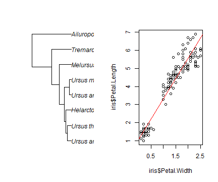

```julia
# Interfacing with other languages
# Calling R

using RCall
R"""
library(ape)
library(BDS)

data(bears)
par(mfrow = c(1,2))
plot(bears, cex = 1)
plot(iris$Petal.Width, iris$Petal.Length)
abline(lm(Petal.Length ~ Petal.Width, data = iris), col = "red")
""";
```

## Differentiable programming

There are many applications where we want to compute derivatives of functions. Here is the finite difference method:

[figure not shown]

By the design of the language, Automatic Differentiation is easy to implement, and so people have developed many packages to do so:

- ForwardDiff.jl
- ReverseDiff.jl
- Zygote.jl
- AutoGrad.jl, and many others

source: https://juliadiff.org/

## Forward-mode automatic differentiation using dual numbers

`f(x1, x2) = sin(x1) + x1 * x2`

example from: https://en.wikipedia.org/wiki/Automatic_differentiation

[figure not shown]

```julia
using ForwardDiff

f(x1, x2) = sin(x1) + x1 * x2
f(x) = f(x[1], x[2])

ForwardDiff.gradient(f, [0.5, 0.5])
```

```
2-element Vector{Float64}:
 1.3775825618903728
 0.5
```

```julia
xb = [-1:0.05:1;]
yb = [-1:0.05:1;]
h = zeros(length(xb), length(yb))
for (i, x) in enumerate(xb), (j, y) in enumerate(yb)
    h[i,j] = f(x,y)
end
p1 = surface(xb, yb, f)
p2 = heatmap(xb, yb, h, xlab = "x1", ylab = "x2")
xs = ys = [-0.9:0.2:0.9;]
for x in xs, y in ys
    d = ForwardDiff.gradient(f, [x, y]) .* 0.1
    quiver!(p2, [x], [y], quiver = ([d[1]], [d[2]]), color = "black")
end
scatter!(p2, [0.5], [0.5], lab = "")
p2
```

[figure not shown]

## Hamiltonian Monte Carlo

Consider a simple birth-death model with speciation rate `λ` and extinction rate `µ`

In Hamiltonian Monte Carlo, the proposals are decided using the Hamiltonian dynamics, which takes advantage of the gradient information. In other words, we need to compute `dlogL / dλ`, as well as `dlogL / dµ`, evaluated at the current position `λ` and `µ` in the Monte Carlo simulation.

[figure not shown]

## Constant-rate birth-death model

$$ \begin{aligned} \frac{dE}{dt} &= \mu - E \cdot (\lambda + \mu) + E^2 \lambda \\ \frac{dM}{dt} &= M \lambda \cdot (E - 1) \end{aligned} $$

Initial conditions:

- $E_0$: The probability of not being sampled at the present: `1 - ρ`
- $M_0$: The number of taxa at the present

The likelihood of a reconstructed phylogenetic tree under the constant-rate birth-death model.  
Conditional on that at least two species must have survived until the present:

$$ L = \frac{M^2(t_0)}{M_0^{n+1}} \prod_{i=2}^n \Big [- \frac{dM}{dt} \Big |_{t_i} \Big ] $$

- $t_i$: the branching times
- $t_0$: the root age

```julia
function dEdM(du, u, p, t)
    λ, μ = p
    # dE/dt -- the extinction probability
    du[1] = μ - u[1] * (λ + μ) + λ * u[1]^2
    # dM/dt -- the number of expected lineages in the reconstructed tree
    du[2] = u[2] * λ * (u[1] - 1.0)
end

using Distributions

struct BDconstant <: Distributions.ContinuousUnivariateDistribution
    λ
    μ
end
```

```julia
data = Dict(
    "root_age" => 65.091686,
    "ρ" => 233 / 367,
    "ntip" => 233,
    "branching_times" => [65.091686, 51.870521, 20.922404, 8.520696, 3.644984, 1.449862,
7.327325, 3.574103, 6.316184, 5.403507, 2.364342, 1.461156, 4.242643,
16.341328, 4.70362799999999, 1.88177099999999, 9.200565, 2.672476,
39.482385, 27.516179, 22.034808, 17.17224, 11.199941, 7.60089599999999,
5.02862699999999, 3.00292999999999, 1.36316299999999, 0.453227999999996,
13.059529, 6.22906799999999, 5.66244499999999, 5.34290799999999,
11.892738, 6.376583, 3.07403499999999, 3.75691, 3.684015, 13.616795,
7.43523599999999, 5.87982599999999, 1.54141899999999, 17.03544,
11.470706, 7.05337099999999, 4.09978599999999, 2.73741999999999,
9.40046999999999, 62.600122, 35.182476, 15.300948, 0.257422999999989,
8.68355399999999, 51.225038, 30.152179, 25.316289, 20.972602,
11.880745, 8.122417, 3.688446, 3.70051, 10.233816, 6.549583,
3.789893, 1.755629, 16.47141, 13.302976, 7.32881399999999, 3.085809,
0.655408999999992, 10.303456, 8.000363, 4.724421, 1.98277, 5.327291,
2.350548, 2.323717, 20.683502, 12.729944, 0.502262000000002,
6.926354, 4.527305, 2.947095, 1.758686, 0.793143999999998, 11.286509,
4.692947, 3.038404, 2.037352, 1.215003, 2.88507, 9.03084399999999,
2.92191, 25.692876, 23.186567, 7.26239, 3.963779, 0.141183999999996,
8.420866, 6.824135, 3.943009, 1.76531199999999, 22.028904, 15.787336,
3.416191, 11.746096, 4.52271499999999, 8.668907, 6.289866, 4.16430099999999,
2.63152299999999, 1.23779399999999, 18.987614, 18.376967, 11.365038,
3.70600899999999, 2.079202, 11.200239, 3.43335499999999, 0.510544999999993,
0.265541999999996, 0.256346999999991, 15.646319, 7.67864699999999,
6.62526699999999, 3.83733699999999, 12.682661, 7.87820199999999,
3.27912999999999, 3.30920499999998, 9.81877099999999, 7.67802699999999,
4.386889, 1.95379199999999, 5.07992299999999, 3.03885799999999,
1.38319699999999, 32.417031, 19.636876, 15.844633, 6.414492,
5.067395, 1.953691, 5.87585599999999, 4.01157899999999, 3.53900599999999,
3.51683199999999, 3.10083699999999, 2.029256, 0.88192699999999,
4.01896899999999, 1.80652799999999, 0.788241999999997, 18.336764,
13.60669, 8.89218099999999, 8.88660099999999, 6.92966499999999,
6.80863799999999, 5.12240199999999, 3.73466199999999, 2.896936,
0.79484699999999, 0.752116999999984, 0.694338999999985, 6.552103,
3.807393, 1.894279, 1.588856, 0.220761999999993, 1.550733, 0.527180999999999,
0.532443000000001, 5.19938499999999, 8.00141999999999, 3.87109199999999,
2.60968899999999, 1.03784599999999, 3.483864, 11.95809, 5.26084199999999,
3.49501299999999, 4.31325399999999, 1.75507999999999, 6.03734699999999,
3.49057099999999, 0.805244999999985, 11.254552, 9.240849, 6.710006,
5.442184, 1.965892, 2.313097, 0.503238999999994, 2.228041, 1.542749,
7.491107, 6.256466, 3.580712, 2.648264, 0.135277000000002, 1.653295,
2.244768, 4.43266199999999, 2.80100299999999, 1.70813799999999,
0.716124999999991, 1.05538199999999, 2.22959599999999, 0.912747999999993,
0.269010999999992, 8.282985, 6.749635, 5.725097, 5.180707, 4.912272,
0.841441000000003, 0.00861799999999846, 4.215321, 3.633333, 2.558834,
1.240261, 0.786479, 0.77825399999999, 2.953571, 2.322968, 1.708579,
1.032298, 0.502719999999997, 0.488648999999995, 0.753017999999997,
0.954774999999998, 1.234458],
)
```

```
Dict{String, Any} with 4 entries:
  "ntip"            => 233
  "root_age"        => 65.0917
  "branching_times" => [65.0917, 51.8705, 20.9224, 8.5207, 3.64498, 1.44986, 7.…
  "ρ"               => 0.634877
```

```julia
function Distributions.loglikelihood(model::BDconstant, data)
    E0 = 1.0 - data["ρ"]
    M0 = data["ntip"]
    alg = DifferentialEquations.Tsit5()

    root_age = maximum(data["branching_times"])
    tspan = (0.0, data["root_age"])

    u0 = [E0, M0]
    p = [model.λ, model.μ]
    prob = DifferentialEquations.ODEProblem(dEdM, u0, tspan, p)
    EM = DifferentialEquations.solve(prob, alg, saveat = data["branching_times"],
                                     isoutofdomain = (u,p,t)->any(x->x<0,u))
    E(t) = EM(t)[1]
    M(t) = EM(t)[2]

    dM(t) = EM(t, Val{1})[2] # The first derivative of M(t)
    n = length(data["branching_times"])

    Mroot = M(root_age)
    if Mroot < 0
        return -Inf
    end
    logL = 2* log(M(root_age)) - (n+1) * log(M0)
    for i in 2:n
        x = -dM(data["branching_times"][i])
        if x < 0
            return -Inf
        end
        logL += log(x)
    end
    return(logL)
end
```

```julia
using Turing

Turing.@model function birthdeath_constant(data)
    μ ~ Distributions.Exponential(0.1)
    d ~ Distributions.Exponential(0.1) # "net-diversification"

    λ = μ + d

    data ~ BDconstant(λ, μ)
end

chain = Turing.sample(birthdeath_constant(data), Turing.NUTS(), 3000; progress=true);
```

[output not shown]

[output cut: 9 more lines]

[output not shown]

```julia
chain
```

```
Chains MCMC chain (3000×14×1 Array{Float64, 3}):

Iterations        = 1001:1:4000
Number of chains  = 1
Samples per chain = 3000
Wall duration     = 23.28 seconds
Compute duration  = 23.28 seconds
parameters        = μ, d
internals         = lp, n_steps, is_accept, acceptance_rate, log_density, hamiltonian_energy, hamiltonian_energy_error, max_hamiltonian_energy_error, tree_depth, numerical_error, step_size, nom_step_size

Summary Statistics
  parameters      mean       std   naive_se      mcse         ess      rhat    ⋯
      Symbol   Float64   Float64    Float64   Float64     Float64   Float64    ⋯

           μ    0.2039    0.0443     0.0008    0.0013   1061.4714    1.0024    ⋯
           d    0.0882    0.0164     0.0003    0.0005   1121.0578    1.0029    ⋯
                                                                1 column omitted

Quantiles
  parameters      2.5%     25.0%     50.0%     75.0%     97.5%
      Symbol   Float64   Float64   Float64   Float64   Float64

           μ    0.1171    0.1746    0.2023    0.2322    0.2925
           d    0.0557    0.0773    0.0883    0.0991    0.1220
```

```julia
pscatter = scatter(chain[:d] .+ chain[:μ], chain[:μ], xlab = "λ", ylab = "μ")
```

[figure not shown]

```julia
λb = [0.15:0.01:0.45;]
µb = [0.05:0.01:0.35;]
h = zeros(length(λb), length(μb))
function f2(λ, μ)
    model = BDconstant(λ, μ)
    res = Distributions.loglikelihood(model, data)
end
f2(x) = f2(x[1], x[2])
for (i, λ) in enumerate(λb), (j, μ) in enumerate(μb)
    h[i,j] = f2(λ, µ)
end
p1 = surface(λb, µb, f2, colorbar = :false, xlab = "λ", ylab = "µ", zlab = "logL")

using DataFrames
chaindf = DataFrame(chain)
first_n = 200
x = chaindf[1:first_n, "μ"] + chaindf[1:first_n, "d"]
y = chaindf[1:first_n, "μ"]
z = chaindf[1:first_n, "lp"]#; z[z .< maximum(z) - 2] .= maximum(z) - 2
scatter!(p1, x, y, z, legend = :none)

p2 = heatmap(λb, µb, h, xlab = "λ", ylab = "μ", colorbar = :none)
xs = [0.15:0.03:0.45;]
ys = [0.05:0.03:0.35;]

for x in xs, y in ys
    d = ForwardDiff.gradient(f2, [x, y]) .* 0.00002
    quiver!(p2, [x], [y], quiver = ([d[1]], [d[2]]), color = "black")
end
```

```julia
plot(p1, p2)
```

[figure not shown]

## Taking a step back

Julia is immensely flexible, but it has some drawbacks

- Small community, difficult to google problems
- Fewer packages than in Python/R/C++
- Debugging/errors: the stacktraces are often uninformative, or too large to interpret
- Documentation, like `?median`, is often lacking since methods are generated
- Can't compile static binaries
- Some startup-time due to JIT compiler. Time-to-first-plot is longer than in R/Matlab/Python
- 1-based indexing
- Garbage-collected, so not good for real-time applications (games, audio/video processing etc.)

Some other Biology-related projects:

- Phylonetworks: https://crsl4.github.io/PhyloNetworks.jl/stable/
  - Phylogenetic network estimation using quartets, as well as trait evolution on networks
- PANDA.jl: https://github.com/hmorlon/PANDA.jl
  - Diversification analyses

## Lineage-specific birth-death model

[figure not shown]